# Images as functions

In the case of colored images, the $a_{ij}$'s are vectors of three elements corresponding to red-green-blue intensity values. This is only one way of representing colored images. There are a number of other possibilities. A popular example is the [hue-saturation-value (HSV)](https://en.wikipedia.org/wiki/HSL_and_HSV).

## RGB system

The RGB system decomposes the image in three channels: Red, Green and Blue.

[figure not shown]

The intensity vales are stored in a 2D matrix for each channel. Here we see an example of the color decompositions:

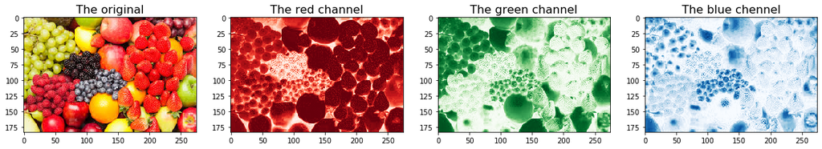

The numbers on the x and y axis show the indices of the points, or on other terms, the indices of the elements in the matrix.

The same for the famous Lenna's picture:

[figure not shown]

Now to see the intensities in a comparable way, we show all in the gray scale. The most left image is the combination of all three channels, i.e., the gray scale version of the original picture.

[figure not shown]

Probably it is more obvious that the image is an intensity function of space when we see the 3D surface plot of the gray scale intensity of the original picture (the summed over the channels):

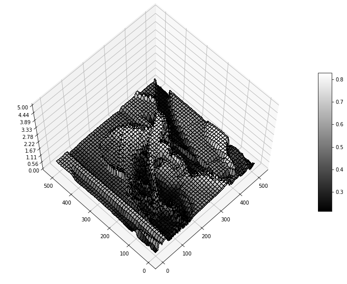

## The HSL/HSV system

HSL (hue, saturation, lightness) and HSV (hue, saturation, value) are alternative representations of the RGB color model, designed in the 1970s by computer graphics researchers to more closely align with the way human vision perceives color-making attributes. In these models, colors of each hue are arranged in a radial slice, around a central axis of neutral colors which ranges from black at the bottom to white at the top. The HSV representation models the way paints of different colors mix together, with the saturation dimension resembling various tints of brightly colored paint, and the value dimension resembling the mixture of those paints with varying amounts of black or white paint. The HSL model attempts to resemble more perceptual color models such as the Natural Color System (NCS) or Munsell color system, placing fully saturated colors around a circle at a lightness value of 1⁄2, where a lightness value of 0 or 1 is fully black or white, respectively.

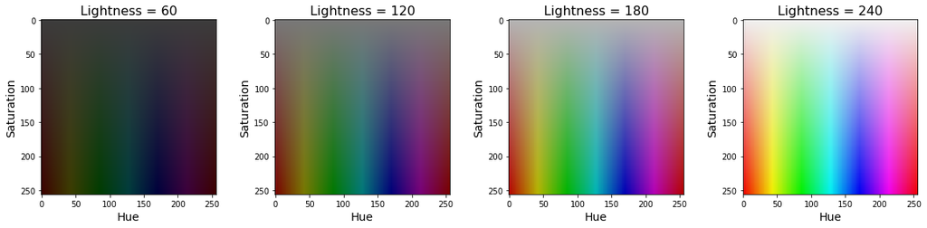

Now let us decompose the pictures in HSV system:

[figure not shown]